# EDRM878 Assignment5

Tiejun Zhang

### 9.7. After the explosion of the space shuttle Challenger on January 28, 1986, a study was conducted [1, 4] to determine if previously-collected data about the ambient air temperature at the time of launch could have been used to foresee potential problems with the launch (Table 4.1; data set: shuttles).In Example 4.2, a model was proposed for these data.

```r
data(shuttles)
head(shuttles)
```

|  | Temp | Damaged |
| --- | --- | --- |
| 1 | 53 | 2 |
| 2 | 57 | 1 |
| 3 | 58 | 1 |
| 4 | 63 | 1 |
| 5 | 66 | 0 |
| 6 | 67 | 0 |

```r
summary(shuttles)
```

[output not shown]

#### 1. Plot the data.

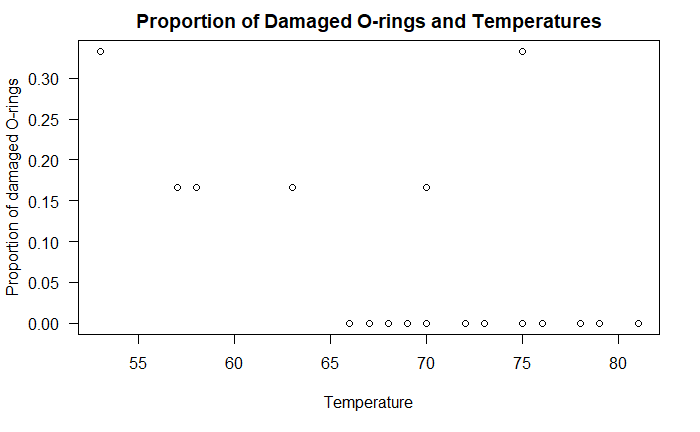

```r
plot(shuttles$Damaged/6 ~ shuttles$Temp,
     las = 1,
     main = "Proportion of Damaged O-rings and Temperatures",
     ylab = "Proportion of damaged O-rings",
     xlab = "Temperature")
```

The O-rings tend to fail more often at low temperatures.

#### 2. Fit and interpret the proposed model.

```r
# fit the model
shuttle.model <- glm(Damaged/6 ~ Temp,
                data = shuttles,
                family = binomial,
                weights=rep(6, length(Temp)))
# the effect of temperature on O-ring failure
coef(shuttle.model)
```

```
(Intercept)        Temp
  5.0849772  -0.1156012
```

```r
# the temperature drops by 1 Fahrenheit
exp(-coef(shuttle.model)[2])
```

```
    Temp
1.122548
```

```r
# the temperature drops by 10 Fahrenheit
exp(-10*coef(shuttle.model)[2])
```

```
    Temp
3.177236
```

The odds of O-ring failure increase by 1.12times for every 1 Fahrenheit drop in temperature, and the odds increase by 3.18 times if the temperature drops 10 Fahrenheit.

#### 3. Perform a diagnostic analysis.

Check for Overdispersion

```r
c(Df = df.residual(shuttle.model),
  Resid.dev = deviance(shuttle.model),
  Pearson.X2 = sum(resid(shuttle.model, type = "pearson")^2))
```

```
        Df  Resid.dev Pearson.X2
  21.00000   18.08633   29.98029
```

The residual deviance is smaller than the residual degrees of freedom and Pearson statistics is a bit greater than the residual degrees of freedom, not enough evidence to support overdispersion.

Quantile Residuals vs Fitted Values

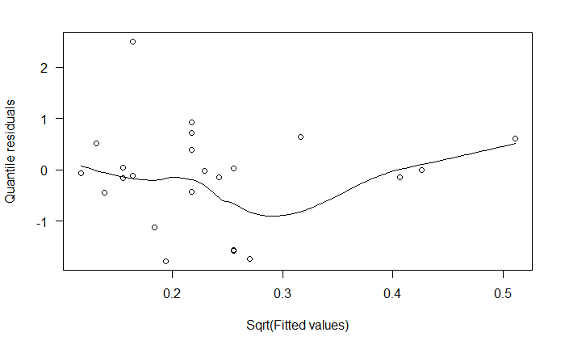

```r
qres <- qresid(shuttle.model)
scatter.smooth(qres ~ sqrt(fitted(shuttle.model)),
               ylab = "Quantile residuals",
               xlab = "Sqrt(Fitted values)",
               las = 1)
```

Q-Q plot

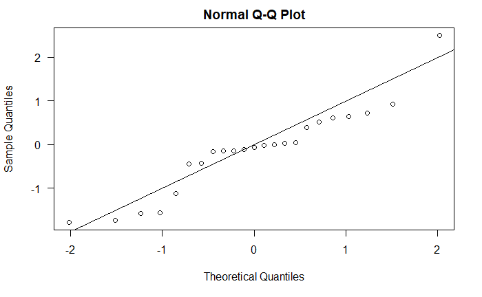

```r
qqnorm(qres, las = 1)
abline(0, 1)
```

The Q-Q plot looks acceptable.

Outliers

```r
rs <- cbind(rD = resid(shuttle.model),
            "r'D" = rstandard(shuttle.model),
            "r''" = rstudent(shuttle.model),
            rQ = qresid(shuttle.model))
head(rs)
```

[output not shown]

```r
apply(abs(rs), 2, max)
```

```
      rD      r'D      r''       rQ
2.651517 2.732593 2.891727 2.774467
```

The maximum all four types of resduals are greater than 2.5, but this shoud not be a big concern as suggeted by the Q-Q plot.

Influential observations

```r
im <- influence.measures(shuttle.model)
colSums(im$is.inf)
```

[output not shown]

```r
rowSums(im$is.inf)
```

[output not shown]

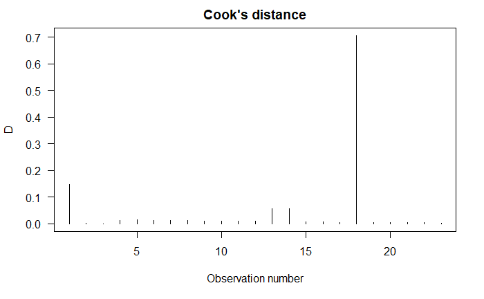

```r
plot(cooks.distance(shuttle.model), type = "h", main = "Cook's distance", ylab = "D", xlab = "Observation number", las = 1)
```

1 observations have high leverage, as identified by the column labelled hat, 4 observations are identified by the covariance ratio as influential, 1 observation is identified by the DIFFITS as influential, but Cook’s distance does not identify any observation as influential.

```r
predict(model.logit, newdata=data.frame(Temp=31), type="response")
```

```
        1
0.8177744
```

#### 5. What would the ed50 mean in this context? What would be a more sensible ed for this context?

```r
library(MASS)
ED50s <- dose.p(shuttle.model)
ED50s
```

```
             Dose       SE
p = 0.5: 43.98725 8.880987
```

The ED50 refers to the temperature(44 Fahrenheit) at which 50% of the O-rings fail. In this case we want the O-ring failures as less as possible, a lower ED, which means less O-ring failures, is perfered.

### 10.12. In a study of depressed women [15], women were classified into groups (Table 10.15; data set: dwomen) based on their depression level (Depression), whether a severe life event had occurred in the last year (SLE), and if they had three children under 14 at home (Children). Model these counts using a Poisson glm, and summarize the data if possible.

#### Data Preparation

```r
data(dwomen)
head(dwomen)
```

|  | Counts | Depression | SLE | Children |
| --- | --- | --- | --- | --- |
| 1 | 9 | Yes | Yes | Yes |
| 2 | 0 | Yes | No | Yes |
| 3 | 24 | Yes | Yes | No |
| 4 | 4 | Yes | No | No |
| 5 | 12 | No | Yes | Yes |
| 6 | 20 | No | No | Yes |

```r
summary(dwomen)
```

```
     Counts       Depression  SLE    Children
 Min.   :  0.00   No :4      No :4   No :4
 1st Qu.:  7.75   Yes:4      Yes:4   Yes:4
 Median : 16.00
 Mean   : 52.38
 3rd Qu.: 47.75
 Max.   :231.00
```

#### Removing structural zeros

```r
dwomen1 <- subset(dwomen, !(Depression == "Yes" & SLE == "No" & Children == "Yes"))
```

#### Frequncy Tables

```r
dwomen1.tab <- xtabs(Counts ~ Depression + SLE + Children,
               data = dwomen1)
dwomen1.tab
```

[output not shown]

#### Variable Relations

Let us take a look at the relationship between the response and the explanatory variables.

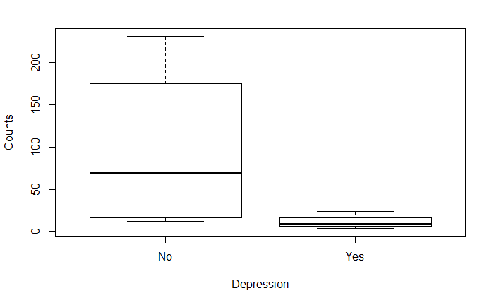

```r
plot(Counts ~ Depression, data = dwomen1)
```

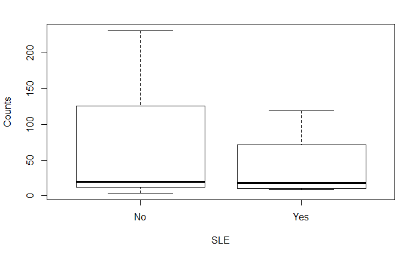

```r
plot(Counts ~ SLE, data = dwomen1)
```

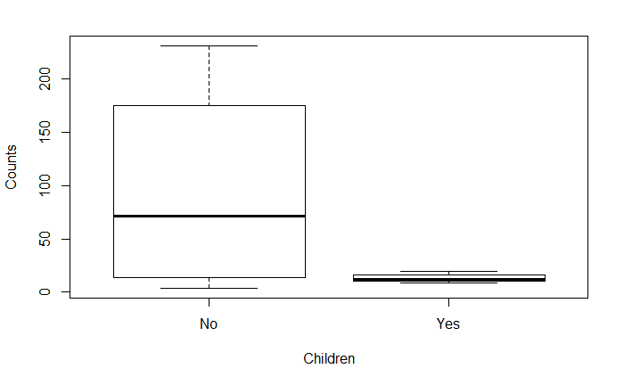

```r
plot(Counts ~ Children, data = dwomen1)
```

#### Fit Model

Let us start with the full model that includes all interactions and see what happens if we drop the three-way interaction.

```r
gm.1 <- glm(Counts ~ Depression * SLE * Children,
            data = dwomen1,
            family = poisson)
drop1(gm.1, test="Chisq")
```

```
Single term deletions

Model:
Counts ~ Depression * SLE * Children
                        Df    Deviance   AIC LRT Pr(>Chi)
<none>                     -8.4377e-15 49.42
Depression:SLE:Children -8.4377e-15 49.42   0
```

The three-way interaction is not necessary in the model. Let us consider dropping each twoway interaction in turn:

```r
gm.2 <- update( gm.1, . ~ (Depression  + SLE+ Children)^2 )
drop1(gm.2, test="Chisq")
```

```
Single term deletions

Model:
Counts ~ Depression + SLE + Children + Depression:SLE + Depression:Children +
    SLE:Children                    Df Deviance    AIC     LRT  Pr(>Chi)
<none>                   0.0000 49.420
Depression:SLE       1  29.7099 77.130 29.7099 5.018e-08 ***
Depression:Children  1   6.6073 54.028  6.6073   0.01016
SLE:Children         1   0.1574 47.578  0.1574   0.69157
---
Signif. codes:  0 *** 0.001 ** 0.01 * 0.05 . 0.1   1
```

The interaction between $SLE$ and $Children$ is not necessary in the model.

Now we fit the model

```r
gm.3 <- glm(Counts ~ Depression * SLE + Depression * Children,
            data = dwomen1,
            family = poisson)
# coefficents and effect size
coef(gm.3)
```

[output not shown]

```r
exp(coef(gm.3))
```

```
              (Intercept)             DepressionYes                    SLEYes               ChildrenYes
             229.97382199                0.01739328                0.52191235                0.09142857
     DepressionYes:SLEYes DepressionYes:ChildrenYes
              11.49618321                4.10156250
```

#### Diagnostic Analysis

Check for Overdispersion

```r
c(Df = df.residual(gm.3),
  Resid.dev = deviance(gm.3),
  Pearson.X2 = sum(resid(gm.3, type = "pearson")^2))
```

```
        Df  Resid.dev Pearson.X2
 1.0000000  0.1573891  0.1593942
```

Quantile Residuals vs Fitted Values

[output not shown]

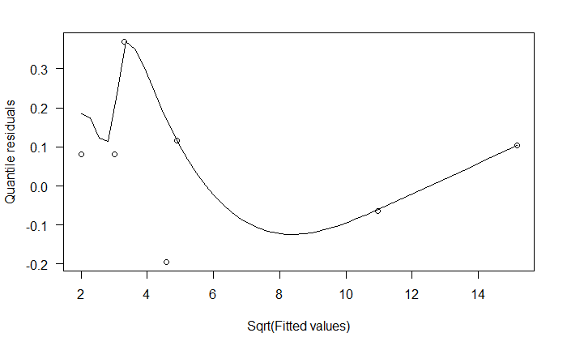

```r
#library(statmod)
qr <- qresid(gm.3)
scatter.smooth(qr ~ sqrt(fitted(gm.3)),
               ylab = "Quantile residuals",
               xlab = "Sqrt(Fitted values)",
               las = 1)
```

Q-Q plot

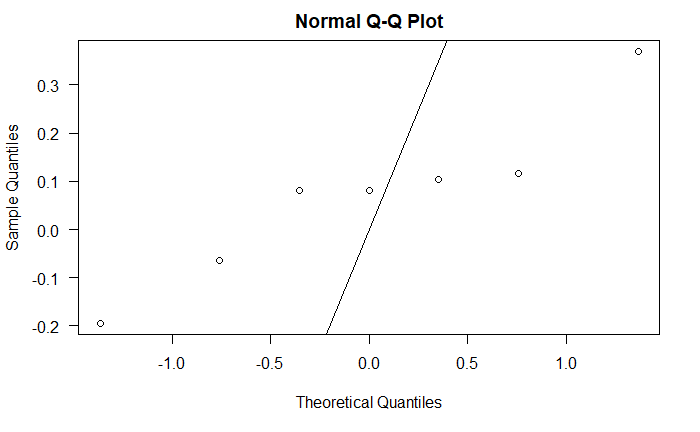

```r
qqnorm(qr, las = 1)
abline(0, 1)
```

Influential observations

```r
im <- influence.measures(gm.3)
colSums(im$is.inf)
```

[output not shown]

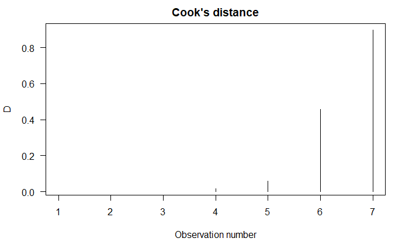

```r
plot(cooks.distance(gm.3), type = "h", main = "Cook's distance", ylab = "D", xlab = "Observation number", las = 1)
```